# PCA Project

## Steps & Tasks:

### 1. Data pre-processing – Perform all the necessary preprocessing on the data ready to be fed to an Unsupervised algorithm

```python
import numpy as np
from sklearn.linear_model import LinearRegression
from sklearn import svm
import pandas as pd
import matplotlib.pyplot as plt
from sklearn.model_selection  import train_test_split
%matplotlib inline
import seaborn as sns
from sklearn.decomposition import PCA
```

```python
vehData = pd.read_csv("vehicle.csv")
vehData.shape
```

```
(846, 19)
```

```python
vehData.head()
```

|  | compactness | circularity | distance_circularity | radius_ratio | pr.axis_aspect_ratio | max.length_aspect_ratio | scatter_ratio | elongatedness | pr.axis_rectangularity | max.length_rectangularity | scaled_variance | scaled_variance.1 | scaled_radius_of_gyration | scaled_radius_of_gyration.1 | skewness_about | skewness_about.1 | skewness_about.2 | hollows_ratio | class |
| --- | --- | --- | --- | --- | --- | --- | --- | --- | --- | --- | --- | --- | --- | --- | --- | --- | --- | --- | --- |
| 0 | 95 | 48.0 | 83.0 | 178.0 | 72.0 | 10 | 162.0 | 42.0 | 20.0 | 159 | 176.0 | 379.0 | 184.0 | 70.0 | 6.0 | 16.0 | 187.0 | 197 | van |
| 1 | 91 | 41.0 | 84.0 | 141.0 | 57.0 | 9 | 149.0 | 45.0 | 19.0 | 143 | 170.0 | 330.0 | 158.0 | 72.0 | 9.0 | 14.0 | 189.0 | 199 | van |
| 2 | 104 | 50.0 | 106.0 | 209.0 | 66.0 | 10 | 207.0 | 32.0 | 23.0 | 158 | 223.0 | 635.0 | 220.0 | 73.0 | 14.0 | 9.0 | 188.0 | 196 | car |
| 3 | 93 | 41.0 | 82.0 | 159.0 | 63.0 | 9 | 144.0 | 46.0 | 19.0 | 143 | 160.0 | 309.0 | 127.0 | 63.0 | 6.0 | 10.0 | 199.0 | 207 | van |
| 4 | 85 | 44.0 | 70.0 | 205.0 | 103.0 | 52 | 149.0 | 45.0 | 19.0 | 144 | 241.0 | 325.0 | 188.0 | 127.0 | 9.0 | 11.0 | 180.0 | 183 | bus |

```python
vehData.info()
```

```
<class 'pandas.core.frame.DataFrame'>
RangeIndex: 846 entries, 0 to 845
Data columns (total 19 columns):
compactness                    846 non-null int64
circularity                    841 non-null float64
distance_circularity           842 non-null float64
radius_ratio                   840 non-null float64
pr.axis_aspect_ratio           844 non-null float64
max.length_aspect_ratio        846 non-null int64
scatter_ratio                  845 non-null float64
elongatedness                  845 non-null float64
pr.axis_rectangularity         843 non-null float64
max.length_rectangularity      846 non-null int64
scaled_variance                843 non-null float64
scaled_variance.1              844 non-null float64
scaled_radius_of_gyration      844 non-null float64
scaled_radius_of_gyration.1    842 non-null float64
skewness_about                 840 non-null float64
skewness_about.1               845 non-null float64
skewness_about.2               845 non-null float64
hollows_ratio                  846 non-null int64
class                          846 non-null object
dtypes: float64(14), int64(4), object(1)
memory usage: 125.7+ KB
```

```python
X = vehData.drop('class',axis=1)
Y = vehData['class']
```

```python
X = X.replace('?', np.nan)
```

```python
#instead of dropping the rows, lets replace the missing values with median value.
X.median()
```

```
compactness                     93.0
circularity                     44.0
distance_circularity            80.0
radius_ratio                   167.0
pr.axis_aspect_ratio            61.0
max.length_aspect_ratio          8.0
scatter_ratio                  157.0
elongatedness                   43.0
pr.axis_rectangularity          20.0
max.length_rectangularity      146.0
scaled_variance                179.0
scaled_variance.1              363.5
scaled_radius_of_gyration      173.5
scaled_radius_of_gyration.1     71.5
skewness_about                   6.0
skewness_about.1                11.0
skewness_about.2               188.0
hollows_ratio                  197.0
dtype: float64
```

```python
# replace the missing values with median value.
# Note, we do not need to specify the column names below
# every column's missing value is replaced with that column's median respectively  (axis =0 means columnwise)

medianFiller = lambda x: x.fillna(x.median())
X = X.apply(medianFiller,axis=0)
```

### 2. Understanding the attributes - Find relationship between different attributes (Independent variables) and choose carefully which all attributes have to be a part of the analysis and why

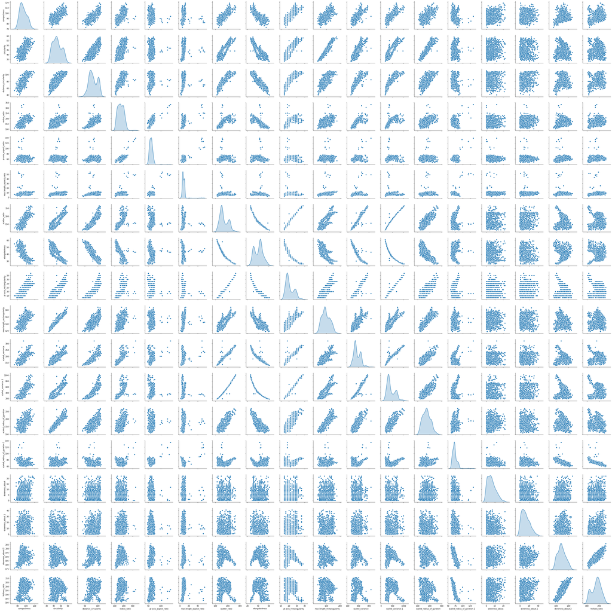

```python
sns.pairplot(X, diag_kind='kde')
```

### 3. Split the data into train and test (Suggestion: specify “random state” if you are using train_test_split from Sklearn)

```python
#X = vehData.drop('class',axis=1)     # Predictor feature columns (8 X m)
#Y = vehData['class']   # Predicted class (no=True, yes=False) (1 X m)

x_train, x_test, y_train, y_test = train_test_split(X, Y, test_size=0.3, random_state=1)
# 1 is just any random seed number

x_train.head(20)
```

|  | compactness | circularity | distance_circularity | radius_ratio | pr.axis_aspect_ratio | max.length_aspect_ratio | scatter_ratio | elongatedness | pr.axis_rectangularity | max.length_rectangularity | scaled_variance | scaled_variance.1 | scaled_radius_of_gyration | scaled_radius_of_gyration.1 | skewness_about | skewness_about.1 | skewness_about.2 | hollows_ratio |
| --- | --- | --- | --- | --- | --- | --- | --- | --- | --- | --- | --- | --- | --- | --- | --- | --- | --- | --- |
| 350 | 97 | 46.0 | 101.0 | 210.0 | 66.0 | 8 | 192.0 | 35.0 | 22.0 | 151 | 208.0 | 546.0 | 169.0 | 66.0 | 1.0 | 32.0 | 191.0 | 200 |
| 40 | 95 | 48.0 | 104.0 | 214.0 | 67.0 | 9 | 205.0 | 32.0 | 23.0 | 151 | 227.0 | 628.0 | 202.0 | 74.0 | 5.0 | 9.0 | 186.0 | 193 |
| 89 | 80 | 37.0 | 57.0 | 116.0 | 55.0 | 6 | 125.0 | 54.0 | 18.0 | 125 | 142.0 | 229.0 | 132.0 | 81.0 | 8.0 | 5.0 | 178.0 | 184 |
| 427 | 86 | 38.0 | 89.0 | 176.0 | 59.0 | 9 | 169.0 | 39.0 | 20.0 | 132 | 190.0 | 428.0 | 148.0 | 67.0 | 7.0 | 33.0 | 193.0 | 202 |
| 353 | 81 | 47.0 | 69.0 | 146.0 | 64.0 | 6 | 151.0 | 44.0 | 19.0 | 147 | 171.0 | 340.0 | 195.0 | 75.0 | 5.0 | 0.0 | 183.0 | 188 |
| 68 | 86 | 44.0 | 78.0 | 164.0 | 68.0 | 9 | 142.0 | 46.0 | 18.0 | 147 | 168.0 | 305.0 | 171.0 | 70.0 | 1.0 | 11.0 | 190.0 | 201 |
| 309 | 109 | 48.0 | 107.0 | 215.0 | 62.0 | 10 | 205.0 | 32.0 | 23.0 | 158 | 222.0 | 624.0 | 168.0 | 65.0 | 9.0 | 32.0 | 195.0 | 206 |
| 139 | 91 | 42.0 | 80.0 | 162.0 | 66.0 | 8 | 148.0 | 44.0 | 19.0 | 145 | 171.0 | 331.0 | 147.0 | 70.0 | 3.0 | 5.0 | 189.0 | 199 |
| 565 | 101 | 48.0 | 85.0 | 191.0 | 60.0 | 11 | 175.0 | 38.0 | 21.0 | 153 | 192.0 | 458.0 | 187.0 | 62.0 | 5.0 | 22.0 | 197.0 | 210 |
| 118 | 85 | 44.0 | 80.0 | 128.0 | 56.0 | 8 | 150.0 | 46.0 | 19.0 | 144 | 168.0 | 324.0 | 173.0 | 82.0 | 9.0 | 14.0 | 180.0 | 184 |
| 498 | 88 | 36.0 | 53.0 | 113.0 | 57.0 | 3 | 118.0 | 57.0 | 17.0 | 128 | 137.0 | 204.0 | 136.0 | 88.0 | 7.0 | 14.0 | 180.0 | 183 |
| 782 | 87 | 44.0 | 98.0 | 211.0 | 70.0 | 10 | 189.0 | 35.0 | 22.0 | 141 | 214.0 | 535.0 | 178.0 | 71.0 | 2.0 | 21.0 | 187.0 | 194 |
| 570 | 105 | 53.0 | 108.0 | 206.0 | 63.0 | 12 | 222.0 | 31.0 | 25.0 | 168 | 226.0 | 712.0 | 201.0 | 71.0 | 15.0 | 35.0 | 189.0 | 203 |
| 305 | 86 | 45.0 | 73.0 | 152.0 | 63.0 | 6 | 149.0 | 44.0 | 19.0 | 145 | 170.0 | 335.0 | 176.0 | 71.0 | 6.0 | 1.0 | 189.0 | 196 |
| 789 | 90 | 39.0 | 85.0 | 160.0 | 59.0 | 7 | 163.0 | 41.0 | 20.0 | 131 | 189.0 | 396.0 | 158.0 | 71.0 | 7.0 | 13.0 | 186.0 | 192 |
| 529 | 86 | 43.0 | 61.0 | 119.0 | 53.0 | 8 | 150.0 | 46.0 | 19.0 | 144 | 169.0 | 326.0 | 172.0 | 85.0 | 8.0 | 8.0 | 179.0 | 182 |
| 14 | 94 | 49.0 | 79.0 | 203.0 | 71.0 | 5 | 174.0 | 37.0 | 21.0 | 154 | 196.0 | 465.0 | 206.0 | 71.0 | 6.0 | 2.0 | 197.0 | 199 |
| 82 | 94 | 36.0 | 68.0 | 127.0 | 54.0 | 7 | 127.0 | 52.0 | 18.0 | 132 | 155.0 | 242.0 | 116.0 | 66.0 | 1.0 | 2.0 | 195.0 | 196 |
| 590 | 84 | 44.0 | 65.0 | 128.0 | 55.0 | 8 | 150.0 | 46.0 | 19.0 | 148 | 169.0 | 325.0 | 176.0 | 82.0 | 1.0 | 11.0 | 179.0 | 183 |
| 355 | 93 | 42.0 | 88.0 | 188.0 | 62.0 | 10 | 183.0 | 36.0 | 21.0 | 141 | 208.0 | 504.0 | 168.0 | 70.0 | 3.0 | 12.0 | 189.0 | 197 |

```python
print("{0:0.2f}% data is in training set".format((len(x_train)/len(X.index)) * 100))
print("{0:0.2f}% data is in test set".format((len(x_test)/len(X.index)) * 100))
```

```
69.98% data is in training set
30.02% data is in test set
```

```python
def getAccuracy(testSet, predictions):
	correct = 0
	for x in range(len(testSet)):
		if testSet[x]== predictions[x]:
			correct += 1
	return (correct/float(len(testSet))) * 100.0
```

### 4. Train a Support vector machine using the train set and get the accuracy on the test set

```python
from sklearn import svm
clf = svm.SVC(gamma=0.025, C=3)
```

```python
clf.fit(x_train , y_train)
```

```
SVC(C=3, cache_size=200, class_weight=None, coef0=0.0,
    decision_function_shape='ovr', degree=3, gamma=0.025, kernel='rbf',
    max_iter=-1, probability=False, random_state=None, shrinking=True,
    tol=0.001, verbose=False)
```

```python
y_pred = clf.predict(x_test)
```

```python
y_test,y_pred = np.array(y_test),np.array(y_pred)
```

```python
getAccuracy(y_test , y_pred)
```

```
53.54330708661418
```

- The Accuracy of the SVM model is 53.5%

### 5. Perform K-fold cross validation and get the cross validation score of the model

```python
from sklearn.model_selection import cross_val_score
```

```python
clf = svm.SVC(kernel='linear', C=1)
```

```python
scores = cross_val_score(clf, X, Y, cv=5)
```

```python
scores
```

```
array([0.91764706, 0.93529412, 0.95882353, 0.95266272, 0.94610778])
```

```python
print("Accuracy: %0.2f (+/- %0.2f)" % (scores.mean(), scores.std() * 2))
```

```
Accuracy: 0.94 (+/- 0.03)
```

- After K-fold Cross validation, accuracy is over 0.94

### 6. Use PCA from Scikit learn, extract Principal Components that capture about 95% of the variance in the data

```python
from scipy.stats import zscore
vehDataScaled=X.apply(zscore)
vehDataScaled.head()
```

|  | compactness | circularity | distance_circularity | radius_ratio | pr.axis_aspect_ratio | max.length_aspect_ratio | scatter_ratio | elongatedness | pr.axis_rectangularity | max.length_rectangularity | scaled_variance | scaled_variance.1 | scaled_radius_of_gyration | scaled_radius_of_gyration.1 | skewness_about | skewness_about.1 | skewness_about.2 | hollows_ratio |
| --- | --- | --- | --- | --- | --- | --- | --- | --- | --- | --- | --- | --- | --- | --- | --- | --- | --- | --- |
| 0 | 0.160580 | 0.518073 | 0.057177 | 0.273363 | 1.310398 | 0.311542 | -0.207598 | 0.136262 | -0.224342 | 0.758332 | -0.401920 | -0.341934 | 0.285705 | -0.327326 | -0.073812 | 0.380870 | -0.312012 | 0.183957 |
| 1 | -0.325470 | -0.623732 | 0.120741 | -0.835032 | -0.593753 | 0.094079 | -0.599423 | 0.520519 | -0.610886 | -0.344578 | -0.593357 | -0.619724 | -0.513630 | -0.059384 | 0.538390 | 0.156798 | 0.013265 | 0.452977 |
| 2 | 1.254193 | 0.844303 | 1.519141 | 1.202018 | 0.548738 | 0.311542 | 1.148719 | -1.144597 | 0.935290 | 0.689401 | 1.097671 | 1.109379 | 1.392477 | 0.074587 | 1.558727 | -0.403383 | -0.149374 | 0.049447 |
| 3 | -0.082445 | -0.623732 | -0.006386 | -0.295813 | 0.167907 | 0.094079 | -0.750125 | 0.648605 | -0.610886 | -0.344578 | -0.912419 | -0.738777 | -1.466683 | -1.265121 | -0.073812 | -0.291347 | 1.639649 | 1.529056 |
| 4 | -1.054545 | -0.134387 | -0.769150 | 1.082192 | 5.245643 | 9.444962 | -0.599423 | 0.520519 | -0.610886 | -0.275646 | 1.671982 | -0.648070 | 0.408680 | 7.309005 | 0.538390 | -0.179311 | -1.450481 | -1.699181 |

```python
covMatrix = np.cov(vehDataScaled,rowvar=False)
print(covMatrix)
```

```
[[ 1.00118343  0.68569786  0.79086299  0.69055952  0.09164265  0.14842463
   0.81358214 -0.78968322  0.81465658  0.67694334  0.76297234  0.81497566
   0.58593517 -0.24988794  0.23635777  0.15720044  0.29889034  0.36598446]
 [ 0.68569786  1.00118343  0.79325751  0.6216467   0.15396023  0.25176438
   0.8489411  -0.82244387  0.84439802  0.96245572  0.79724837  0.83693508
   0.92691166  0.05200785  0.14436828 -0.01145212 -0.10455005  0.04640562]
 [ 0.79086299  0.79325751  1.00118343  0.76794246  0.15864319  0.26499957
   0.90614687 -0.9123854   0.89408198  0.77544391  0.86253904  0.88706577
   0.70660663 -0.22621115  0.1140589   0.26586088  0.14627113  0.33312625]
 [ 0.69055952  0.6216467   0.76794246  1.00118343  0.66423242  0.45058426
   0.73529816 -0.79041561  0.70922371  0.56962256  0.79435372  0.71928618
   0.53700678 -0.18061084  0.04877032  0.17394649  0.38266622  0.47186659]
 [ 0.09164265  0.15396023  0.15864319  0.66423242  1.00118343  0.64949139
   0.10385472 -0.18325156  0.07969786  0.1270594   0.27323306  0.08929427
   0.12211524  0.15313091 -0.05843967 -0.0320139   0.24016968  0.26804208]
 [ 0.14842463  0.25176438  0.26499957  0.45058426  0.64949139  1.00118343
   0.16638787 -0.18035326  0.16169312  0.30630475  0.31933428  0.1434227
   0.18996732  0.29608463  0.01561769  0.04347324 -0.02611148  0.14408905]
 [ 0.81358214  0.8489411   0.90614687  0.73529816  0.10385472  0.16638787
   1.00118343 -0.97275069  0.99092181  0.81004084  0.94978498  0.9941867
   0.80082111 -0.02757446  0.07454578  0.21267959  0.00563439  0.1189581 ]
 [-0.78968322 -0.82244387 -0.9123854  -0.79041561 -0.18325156 -0.18035326
  -0.97275069  1.00118343 -0.95011894 -0.77677186 -0.93748998 -0.95494487
  -0.76722075  0.10342428 -0.05266193 -0.18527244 -0.11526213 -0.2171615 ]
 [ 0.81465658  0.84439802  0.89408198  0.70922371  0.07969786  0.16169312
   0.99092181 -0.95011894  1.00118343  0.81189327  0.93533261  0.98938264
   0.79763248 -0.01551372  0.08386628  0.21495454 -0.01867064  0.09940372]
 [ 0.67694334  0.96245572  0.77544391  0.56962256  0.1270594   0.30630475
   0.81004084 -0.77677186  0.81189327  1.00118343  0.74586628  0.79555492
   0.86747579  0.04167099  0.13601231  0.00136727 -0.10407076  0.07686047]
 [ 0.76297234  0.79724837  0.86253904  0.79435372  0.27323306  0.31933428
   0.94978498 -0.93748998  0.93533261  0.74586628  1.00118343  0.94679667
   0.77983844  0.11321163  0.03677248  0.19446837  0.01423606  0.08579656]
 [ 0.81497566  0.83693508  0.88706577  0.71928618  0.08929427  0.1434227
   0.9941867  -0.95494487  0.98938264  0.79555492  0.94679667  1.00118343
   0.79595778 -0.01541878  0.07696823  0.20104818  0.00622636  0.10305714]
 [ 0.58593517  0.92691166  0.70660663  0.53700678  0.12211524  0.18996732
   0.80082111 -0.76722075  0.79763248  0.86747579  0.77983844  0.79595778
   1.00118343  0.19169941  0.16667971 -0.05621953 -0.22471583 -0.11814142]
 [-0.24988794  0.05200785 -0.22621115 -0.18061084  0.15313091  0.29608463
  -0.02757446  0.10342428 -0.01551372  0.04167099  0.11321163 -0.01541878
   0.19169941  1.00118343 -0.08846001 -0.12633227 -0.749751   -0.80307227]
 [ 0.23635777  0.14436828  0.1140589   0.04877032 -0.05843967  0.01561769
   0.07454578 -0.05266193  0.08386628  0.13601231  0.03677248  0.07696823
   0.16667971 -0.08846001  1.00118343 -0.03503155  0.1154338   0.09724079]
 [ 0.15720044 -0.01145212  0.26586088  0.17394649 -0.0320139   0.04347324
   0.21267959 -0.18527244  0.21495454  0.00136727  0.19446837  0.20104818
  -0.05621953 -0.12633227 -0.03503155  1.00118343  0.07740174  0.20523257]
 [ 0.29889034 -0.10455005  0.14627113  0.38266622  0.24016968 -0.02611148
   0.00563439 -0.11526213 -0.01867064 -0.10407076  0.01423606  0.00622636
  -0.22471583 -0.749751    0.1154338   0.07740174  1.00118343  0.89363767]
 [ 0.36598446  0.04640562  0.33312625  0.47186659  0.26804208  0.14408905
   0.1189581  -0.2171615   0.09940372  0.07686047  0.08579656  0.10305714
  -0.11814142 -0.80307227  0.09724079  0.20523257  0.89363767  1.00118343]]
```

```python
pca = PCA(n_components=6)
pca.fit(vehDataScaled)
```

```
PCA(copy=True, iterated_power='auto', n_components=6, random_state=None,
    svd_solver='auto', tol=0.0, whiten=False)
```

```python
print(pca.explained_variance_)
```

```
[9.40460261 3.01492206 1.90352502 1.17993747 0.91726063 0.53999263]
```

```python
print(pca.components_)
```

```
[[ 2.75283688e-01  2.93258469e-01  3.04609128e-01  2.67606877e-01
   8.05039890e-02  9.72756855e-02  3.17092750e-01 -3.14133155e-01
   3.13959064e-01  2.82830900e-01  3.09280359e-01  3.13788457e-01
   2.72047492e-01 -2.08137692e-02  4.14555082e-02  5.82250207e-02
   3.02795063e-02  7.41453913e-02]
 [-1.26953763e-01  1.25576727e-01 -7.29516436e-02 -1.89634378e-01
  -1.22174860e-01  1.07482875e-02  4.81181371e-02  1.27498515e-02
   5.99352482e-02  1.16220532e-01  6.22806229e-02  5.37843596e-02
   2.09233172e-01  4.88525148e-01 -5.50899716e-02 -1.24085090e-01
  -5.40914775e-01 -5.40354258e-01]
 [-1.19922479e-01 -2.48205467e-02 -5.60143254e-02  2.75074211e-01
   6.42012966e-01  5.91801304e-01 -9.76283108e-02  5.76484384e-02
  -1.09512416e-01 -1.70641987e-02  5.63239801e-02 -1.08840729e-01
  -3.14636493e-02  2.86277015e-01 -1.15679354e-01 -7.52828901e-02
   8.73592035e-03  3.95242743e-02]
 [ 7.83843562e-02  1.87337408e-01 -7.12008427e-02 -4.26053416e-02
   3.27257120e-02  3.14147276e-02 -9.57485748e-02  8.22901952e-02
  -9.24582989e-02  1.88005612e-01 -1.19844007e-01 -9.17449326e-02
   2.00095228e-01 -6.55051355e-02  6.04794251e-01 -6.66114117e-01
   1.05526253e-01  4.74890312e-02]
 [ 6.95178336e-02 -8.50649539e-02  4.06645651e-02 -4.61473715e-02
  -4.05494487e-02  2.13432566e-01 -1.54853055e-02  7.68518712e-02
   2.17633161e-03 -6.06366845e-02 -4.56472157e-04 -1.95548316e-02
  -6.15991682e-02  1.45530146e-01  7.29189842e-01  5.99196401e-01
  -1.00602332e-01 -2.98614819e-02]
 [ 1.44875475e-01 -3.02731150e-01 -1.38405772e-01  2.48136642e-01
   2.36932607e-01 -4.19330745e-01  1.16100155e-01 -1.41840113e-01
   9.80561314e-02 -4.61674972e-01  2.36225424e-01  1.57820197e-01
  -1.35576276e-01  2.41356824e-01  2.03209256e-01 -1.91960802e-01
   1.56939177e-01 -2.41222819e-01]]
```

```python
print(pca.explained_variance_ratio_)
```

```
[0.52186034 0.16729768 0.10562639 0.0654746  0.05089869 0.02996413]
```

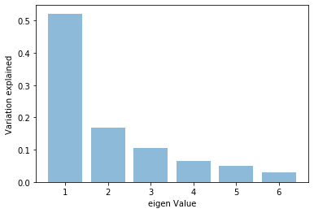

```python
plt.bar(list(range(1,7)),pca.explained_variance_ratio_,alpha=0.5, align='center')
plt.ylabel('Variation explained')
plt.xlabel('eigen Value')
plt.show()
```

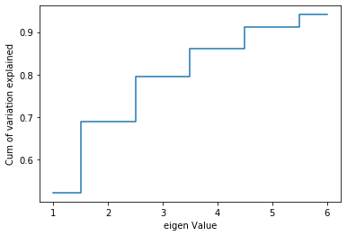

```python
plt.step(list(range(1,7)),np.cumsum(pca.explained_variance_ratio_), where='mid')
plt.ylabel('Cum of variation explained')
plt.xlabel('eigen Value')
plt.show()
```

### 7. Repeat steps 3,4 and 5 but this time, use Principal Components instead of the original data. And the accuracy score should be on the same rows of test data that were used earlier.

```python
pca3 = PCA(n_components=5)
pca3.fit(vehDataScaled)
print(pca3.components_)
print(pca3.explained_variance_ratio_)
Xpca3 = pca3.transform(vehDataScaled)
```

```
[[ 2.75283688e-01  2.93258469e-01  3.04609128e-01  2.67606877e-01
   8.05039890e-02  9.72756855e-02  3.17092750e-01 -3.14133155e-01
   3.13959064e-01  2.82830900e-01  3.09280359e-01  3.13788457e-01
   2.72047492e-01 -2.08137692e-02  4.14555082e-02  5.82250207e-02
   3.02795063e-02  7.41453913e-02]
 [-1.26953763e-01  1.25576727e-01 -7.29516436e-02 -1.89634378e-01
  -1.22174860e-01  1.07482875e-02  4.81181371e-02  1.27498515e-02
   5.99352482e-02  1.16220532e-01  6.22806229e-02  5.37843596e-02
   2.09233172e-01  4.88525148e-01 -5.50899716e-02 -1.24085090e-01
  -5.40914775e-01 -5.40354258e-01]
 [-1.19922479e-01 -2.48205467e-02 -5.60143254e-02  2.75074210e-01
   6.42012966e-01  5.91801304e-01 -9.76283108e-02  5.76484384e-02
  -1.09512416e-01 -1.70641988e-02  5.63239801e-02 -1.08840729e-01
  -3.14636493e-02  2.86277015e-01 -1.15679354e-01 -7.52828901e-02
   8.73592034e-03  3.95242743e-02]
 [ 7.83843560e-02  1.87337407e-01 -7.12008428e-02 -4.26053406e-02
   3.27257115e-02  3.14147276e-02 -9.57485749e-02  8.22901956e-02
  -9.24582990e-02  1.88005613e-01 -1.19844007e-01 -9.17449327e-02
   2.00095228e-01 -6.55051356e-02  6.04794251e-01 -6.66114117e-01
   1.05526253e-01  4.74890309e-02]
 [ 6.95178324e-02 -8.50649635e-02  4.06645636e-02 -4.61473640e-02
  -4.05494524e-02  2.13432565e-01 -1.54853068e-02  7.68518742e-02
   2.17633116e-03 -6.06366759e-02 -4.56468711e-04 -1.95548332e-02
  -6.15991661e-02  1.45530145e-01  7.29189843e-01  5.99196401e-01
  -1.00602332e-01 -2.98614838e-02]]
[0.52186034 0.16729768 0.10562639 0.0654746  0.05089869]
```

```python
Xpca3
```

```
array([[ 3.34162030e-01, -2.19026358e-01,  1.00158417e+00,
         1.76612370e-01,  7.93007068e-02],
       [-1.59171085e+00, -4.20602982e-01, -3.69033854e-01,
         2.33234117e-01,  6.93948581e-01],
       [ 3.76932418e+00,  1.95282752e-01,  8.78587404e-02,
         1.20221219e+00,  7.31732266e-01],
       ...,
       [ 4.80917387e+00, -1.24931049e-03,  5.32333105e-01,
         2.95652324e-01, -1.34423635e+00],
       [-3.29409242e+00, -1.00827615e+00, -3.57003198e-01,
        -1.93367514e+00,  4.27680054e-02],
       [-4.76505347e+00,  3.34899728e-01, -5.68136078e-01,
        -1.22480708e+00, -5.40510353e-02]])
```

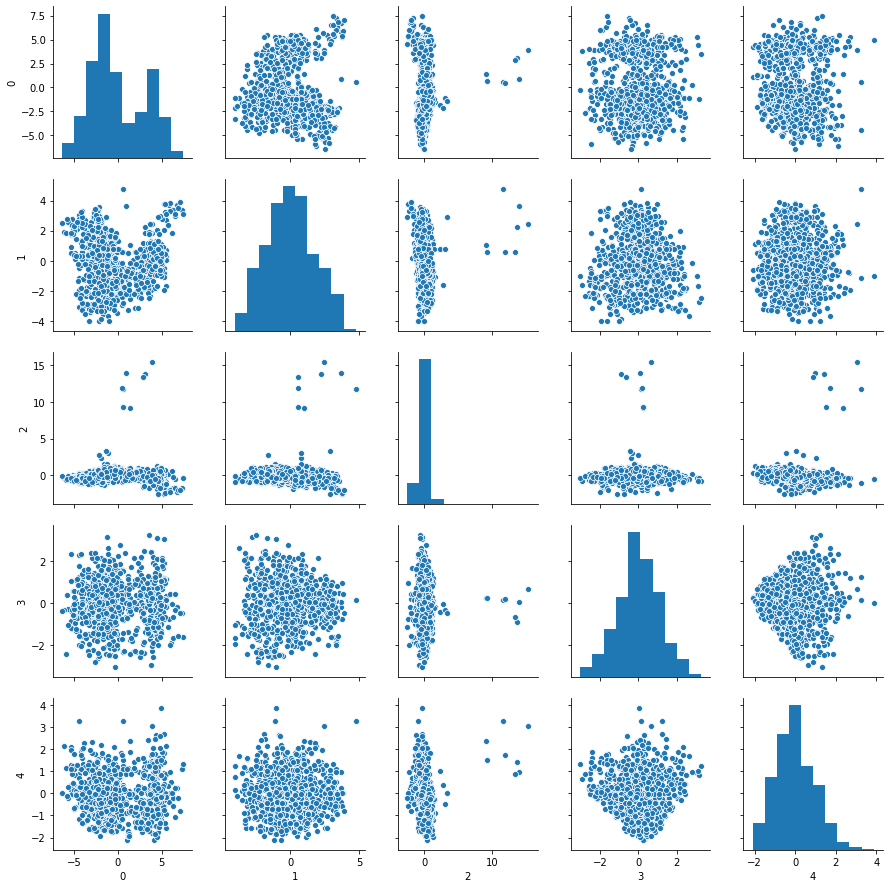

```python
sns.pairplot(pd.DataFrame(Xpca3))
```

```python
regression_model_pca = svm.SVC(gamma=0.025, C=3)
regression_model_pca.fit(Xpca3, Y)
regression_model_pca.score(Xpca3, Y)
```

```
0.7789598108747045
```

- Accuracy with PCA components used is 78%

```python
scores = cross_val_score(clf, Xpca3, Y, cv=5)
```

```python
scores
```

```
array([0.64705882, 0.67058824, 0.69411765, 0.71005917, 0.62874251])
```

```python
print("Accuracy: %0.2f (+/- %0.2f)" % (scores.mean(), scores.std() * 2))
```

```
Accuracy: 0.67 (+/- 0.06)
```

- After K-fold cross validation, we see 0.67 accuracy

### 8. Compare the accuracy scores and cross validation scores of Support vector machines – one trained using raw data and the other using Principal Components, and mention your findings

**Accuracy of SVM model - 53.5% & cross validation score - 0.94 accuracy

**Accuracy of SVM using PCA components - 78% & cross validation score - 0.67 accuracy